# BellaBeat_R-Markdown_v2

```r
head(daily_intensity)
```

```
## # A tibble: 6 × 3
##           Id ActivityDate        Total_intensity
##        <dbl> <dttm>                        <dbl>
## 1 1503960366 2016-04-12 00:00:00             429
## 2 1503960366 2016-04-13 00:00:00             318
## 3 1503960366 2016-04-14 00:00:00             293
## 4 1503960366 2016-04-15 00:00:00             364
## 5 1503960366 2016-04-16 00:00:00             349
## 6 1503960366 2016-04-17 00:00:00             318
```

3. We are checking how correlated between sleep time and total time in bed.

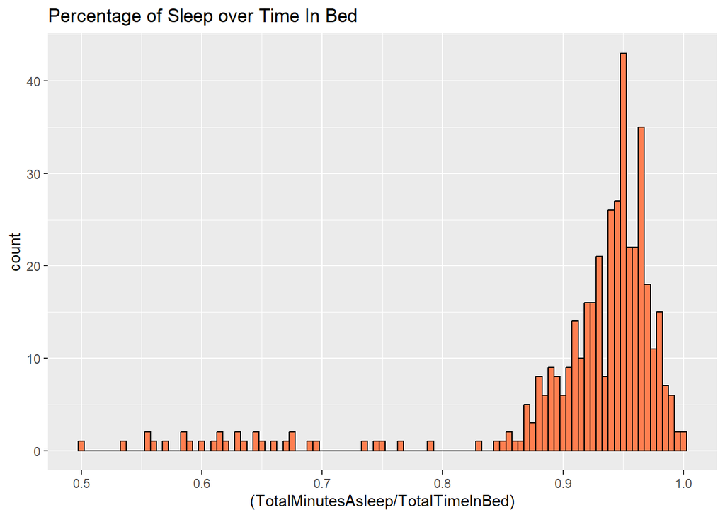

```r
ggplot(data=sleep, mapping=aes(x=(TotalMinutesAsleep/TotalTimeInBed))) + geom_histogram(color='black', fill='coral', binwidth = 0.005) + labs(title = "Percentage of Sleep over Time In Bed")
```

According to the chart, the most percentage people in sleep mode is 95% of time in bed. Almost people fall asleep fast when they are in bed, because the histogram is inclined to the range from 0.94 to 1.0.  
4. We draw visualizations to compare effect of Distance, Steps, and Intensity on burning calories.

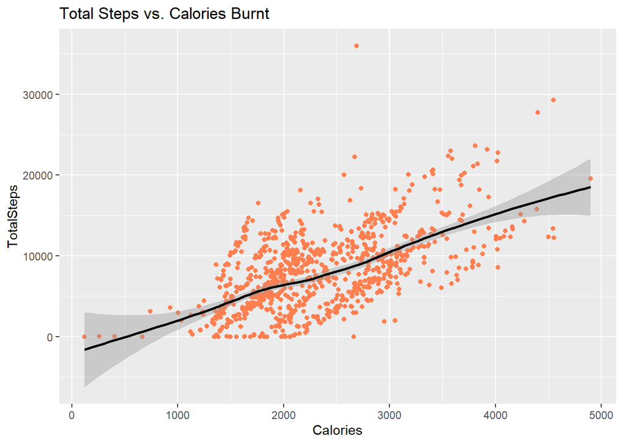

```r
ggplot(data=activity, mapping=aes(x = Calories, y = TotalSteps)) + geom_jitter(color = 'coral') +geom_smooth(color = 'black') + labs(title = "Total Steps vs. Calories Burnt")
```

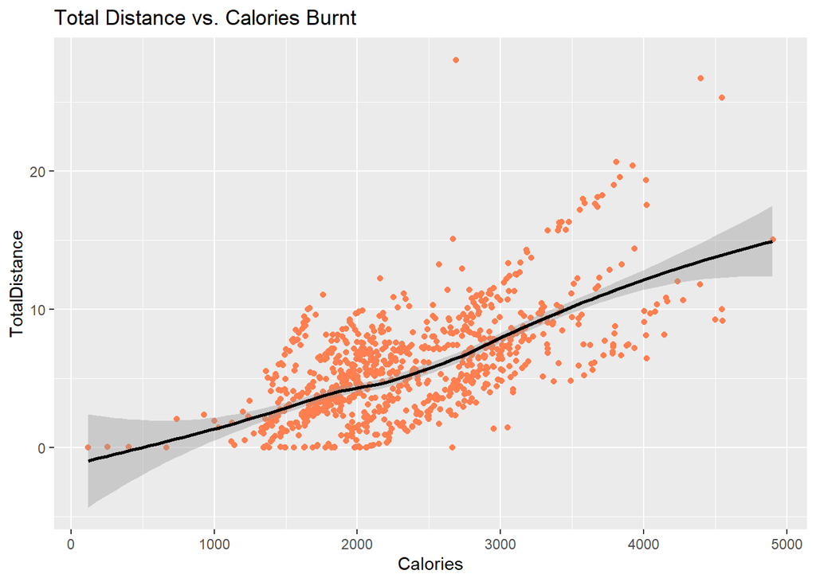

```r
ggplot(data=activity, mapping=aes(x = Calories, y = TotalDistance)) + geom_jitter(color = 'coral') +geom_smooth(color = 'black') + labs(title = "Total Distance vs. Calories Burnt")
```